# Chronic conditions and logistic regression

Matthew Rudd

2/10/2022

# The 2009 NAMCS and chronic conditions

## The null model

```r
chronic.null <- mean( chronic$Condition)

chronic %>%
  group_by(Condition)  %>%
  summarize( N=n(), Percentage = N/nrow(chronic))
```

```
## # A tibble: 2 × 3
##   Condition     N Percentage
##       <dbl> <int>      <dbl>
## 1         0 13303      0.423
## 2         1 18130      0.577
```

## A useless plot

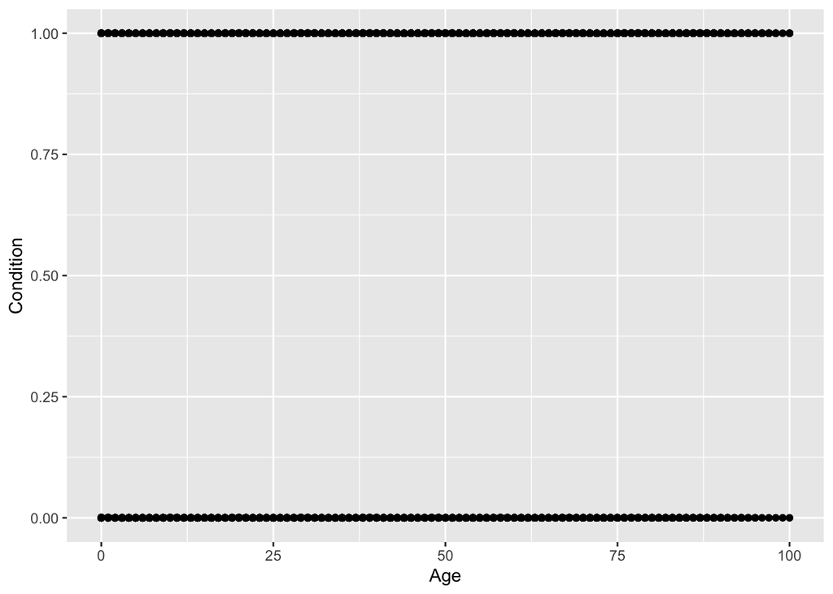

```r
ggplot( chronic, aes(Age, Condition)) + geom_point()
```

## Some useful plots

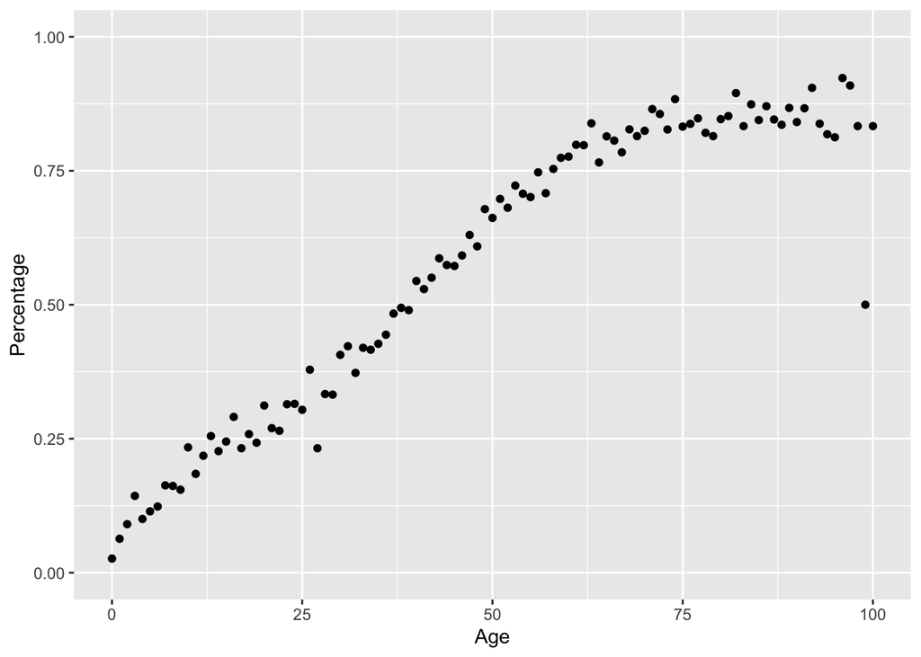

```r
cohorts <- chronic %>%
  group_by(Age) %>%
  summarize( N=n(), Percentage = sum(Condition)/N )

ggplot( cohorts, aes(Age, Percentage)) + geom_point() + ylim(0,1)
```

```r
chronic <- chronic %>%
  mutate( Decade = 10*round(Age/10))

decades <- chronic %>%
  group_by( Decade ) %>%
  summarize( N=n(), Percentage = sum(Condition)/N )

# using knitr's kable function :
# knitr::kable( decades )

# using pander :
# pander( decades )

# using flextable's regulartable function :
regulartable( decades ) %>% autofit()
```

| Decade | N | Percentage |
| --- | --- | --- |
| 0 | 2,440 | 0.07336066 |
| 10 | 1,946 | 0.18910586 |
| 20 | 2,622 | 0.27803204 |
| 30 | 2,673 | 0.37037037 |
| 40 | 3,962 | 0.52246340 |
| 50 | 4,426 | 0.66719385 |
| 60 | 5,356 | 0.77053771 |
| 70 | 3,748 | 0.83004269 |
| 80 | 3,357 | 0.84331248 |
| 90 | 849 | 0.85512367 |
| 100 | 54 | 0.85185185 |

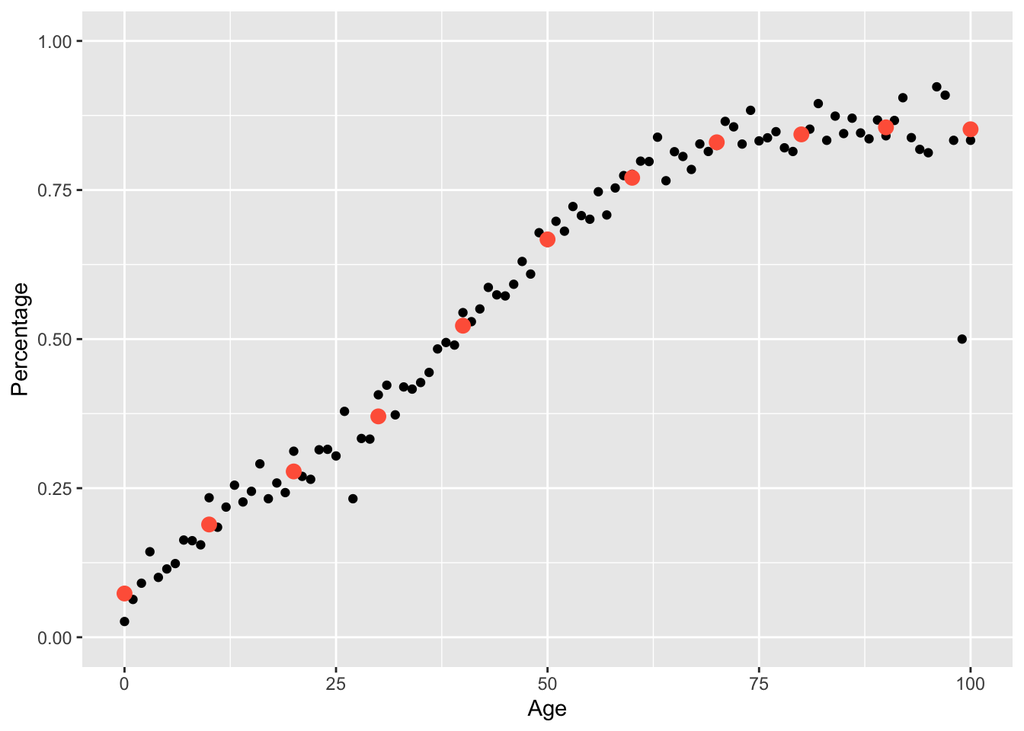

```r
ggplot( cohorts, aes(Age, Percentage)) +
  geom_point() +
  geom_point( data=decades, aes(Decade, Percentage), color="tomato", size=3) +
  ylim(0,1)
```

## The curve of chance

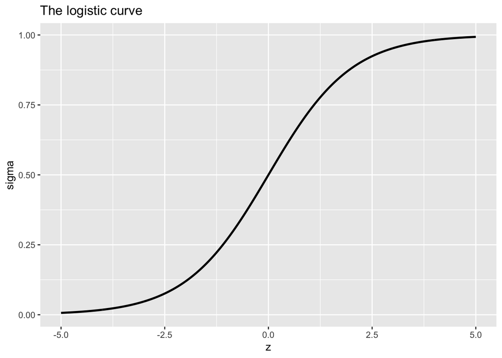

```r
z <- seq(-5, 5, len=1000)
logistic <- data.frame( z=z, sigma = 1 / (1 + exp(-z)))
ggplot( logistic, aes(z,sigma)) +
  geom_line( size=1 ) +
  labs( title = "The logistic curve")
```

This is a plot of the *logistic curve* a.k.a. the *logistic function* a.k.a. the *sigmoid function*

$$\sigma( z ) ~ = ~ \frac{ 1 }{ 1 + e^{-z}} \ .$$

# Fitting the logistic curve to our data

```r
chronic.fit <- glm( Condition ~ Age, data=chronic, family="binomial")
chronic.fit
```

```
##
## Call:  glm(formula = Condition ~ Age, family = "binomial", data = chronic)
##
## Coefficients:
## (Intercept)          Age
##    -2.03938      0.05182
##
## Degrees of Freedom: 31432 Total (i.e. Null);  31431 Residual
## Null Deviance:       42830
## Residual Deviance: 33840     AIC: 33840
```

The *fitted logistic regression model* is therefore

$$\text{Probability of condition} ~ = ~ \sigma( -2.03938 + 0.05182 \times \text{Age}) \ .$$

To phrase this in terms of the odds of having a condition, recall the definition of the odds of something happening:

$$\text{Odds of event} ~ = ~ \frac{ \text{Probability of event} }{ 1 - \text{Probability of event} } \ .$$
In terms of *odds*, our logistic model is

$$\log{ ( \text{Odds of a condition} ) } ~ = ~ -2.03938 + 0.05182 \times \text{Age} \ .$$

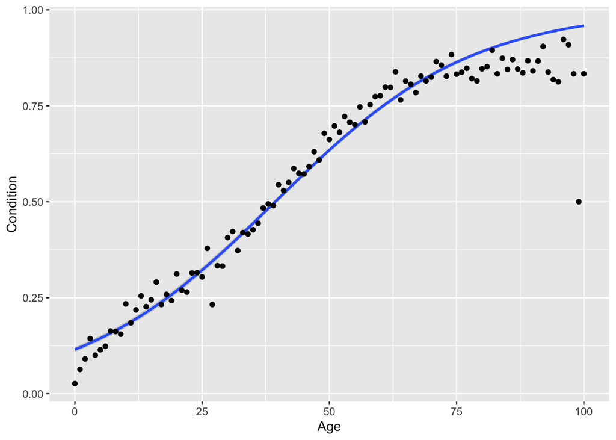

```r
ggplot( chronic, aes(Age, Condition)) +
  geom_smooth( method="glm", method.args=list(family="binomial")) +
  geom_point( data=cohorts, aes(Age, Percentage))
```

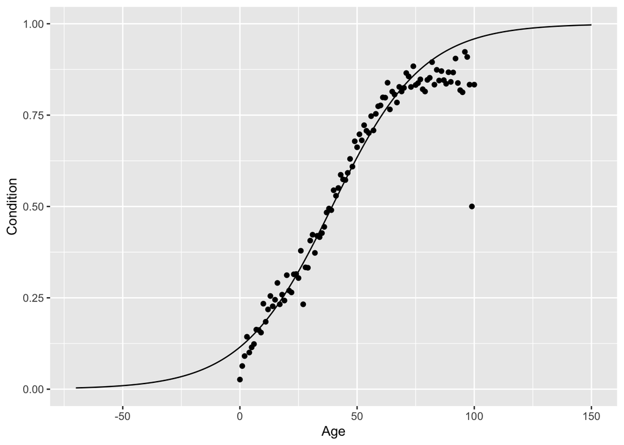

```r
new <- data.frame( Age = seq(-70,150,by=1))
extended <- predict( chronic.fit, new, type="response")
extended <-data.frame( Age = new$Age, Probability = extended )

ggplot( chronic, aes(Age,Condition)) +
  geom_point( data=cohorts, aes(Age, Percentage)) +
  geom_line( data = extended, aes(Age, Probability)) +
  xlim(-70,150)
```

## The odds ratio

One way to summarize this model is to report its *odds ratio*, which is the logistic regression analogue of the slope in linear regression. To derive the expression for the odds ratio, we first need to solve the equation

$$y ~ = ~ \sigma(z) ~ = ~ \frac{ 1 }{ 1 + e^{-z}}$$
for $z$ ; doing the necessary manipulation yields

$$z ~ = ~ \log{ \left( \frac{ y }{ 1 - y } \right) } \ .$$

This inverse function of the logistic function is known as the *logit* : by definition,

$$\operatorname{logit}( y ) ~ = ~ \log{ \left( \frac{ y }{ 1 - y } \right) } \ .$$

Putting this all together, a simple logistic model with predictor variable $x$ has two equivalent forms:

$$\text{Probability of event} = \sigma( a + bx ) \quad \iff \quad \log{(\text{Odds of event})} = a + bx \ .$$

Exponentiating the second form yields yet another formulation:

$$\text{Odds of event} ~ = ~ e^{a+bx} ~ = ~ e^{a} e^{bx} \ .$$
Now we get to the odds ratio. Fix a value $x_{0}$ of the predictor and compare the odds when $x=x_{0}$ to the odds when $x=x_{0}+1$:

$$\text{Odds when} \left\{ x=x_{0}+1 \right\} ~ = ~ e^{a} e^{bx_{0}} e^{b} ~ = ~ e^{b} \times \text{Odds when} \left\{ x=x_{0} \right\} \ .$$

The odds get multiplied by the factor $e^{b}$, which is, by definition, the model’s *odds ratio*.

> The odds ratio tells us how the odds change when the predictor increases by 1 unit: *multiply* the odds by the odds ratio.

For the logistic chronic condition model:

```r
chronic.or <- exp( chronic.fit$coefficients[2] )
chronic.or
```

```
##      Age
## 1.053181
```

The odds ratio is 1.053181, so the odds of having a chronic condition increase by about 5% with each 1 year increase in `Age`. A 10-year increase in `Age` therefore leads to a multiplier of

```r
chronic.or^10
```

```
##      Age
## 1.678923
```

i.e., a 68% increase in the odds of having a chronic condition. A 50-year increase in `Age` leads to a multiplier of

```r
chronic.or^50
```

```
##      Age
## 13.33992
```

so the odds of a random 70-year-old having a chronic condition are more than 13 times the odds of a random 20-year-old having a chronic condition. Ah, the golden years after retirement!

# Binary classification

## Confusion matrices for varying thresholds

```r
# decision boundary where probability = 50% (i.e., odds = 1) :
(threshold <- ( -chronic.fit$coefficients[1] ) / ( chronic.fit$coefficients[2] ))
```

```
## (Intercept)
##    39.35875
```

```r
chronic <- chronic %>%
  mutate( Classifier = as.numeric( Age > threshold ))

# confusion matrix for assessing classifier:
class.table <- table( chronic$Condition, chronic$Classifier)
rownames( class.table ) <- c("No condition", "Has a condition")
colnames( class.table ) <- c("No condition predicted", "Condition predicted")
class.table
```

```
##
##                   No condition predicted Condition predicted
##   No condition                      8294                5009
##   Has a condition                   3043               15087
```

```r
# overall accuracy rate
mean( chronic$Condition == chronic$Classifier)
```

```
## [1] 0.7438361
```

```r
# overall error rate
mean( chronic$Condition != chronic$Classifier)
```

```
## [1] 0.2561639
```

```r
chronic <- chronic %>%
  mutate( Classifier = as.numeric( Age >= 80 ))

# confusion matrix for assessing classifier:
class.table <- table( chronic$Condition, chronic$Classifier)
rownames( class.table ) <- c("No condition", "Has a condition")
colnames( class.table ) <- c("No condition predicted", "Condition predicted")
class.table
```

```
##
##                   No condition predicted Condition predicted
##   No condition                     12947                 356
##   Has a condition                  16005                2125
```

```r
# overall accuracy rate
mean( chronic$Condition == chronic$Classifier)
```

```
## [1] 0.4794961
```

```r
# overall error rate
mean( chronic$Condition != chronic$Classifier)
```

```
## [1] 0.5205039
```

```r
chronic <- chronic %>%
  mutate( Classifier = as.numeric( Age >= 20 ))

# confusion matrix for assessing classifier:
class.table <- table( chronic$Condition, chronic$Classifier)
rownames( class.table ) <- c("No condition", "Has a condition")
colnames( class.table ) <- c("No condition predicted", "Condition predicted")
class.table
```

```
##
##                   No condition predicted Condition predicted
##   No condition                      4719                8584
##   Has a condition                    846               17284
```

```r
# overall accuracy rate
mean( chronic$Condition == chronic$Classifier)
```

```
## [1] 0.6999968
```

```r
# overall error rate
mean( chronic$Condition != chronic$Classifier)
```

```
## [1] 0.3000032
```

### Receiver Operating Characteristic (ROC) curve

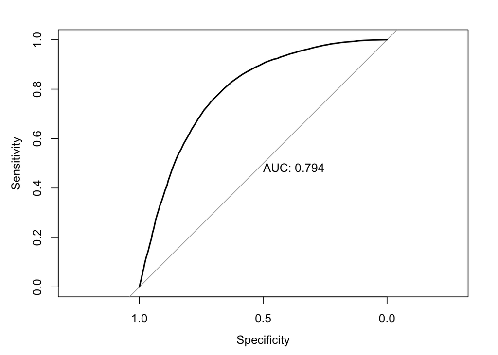

```r
# pROC and ROCR are the 2 standard R packages for computing/plotting ROC curves

library(pROC)
chronic <- chronic %>% mutate(Probability = chronic.fit$fitted.values )
roc.obj <- roc(chronic$Condition,  chronic$Probability, plot=TRUE, print.auc=TRUE)
```